# Evaluating a crystal ball - part 1

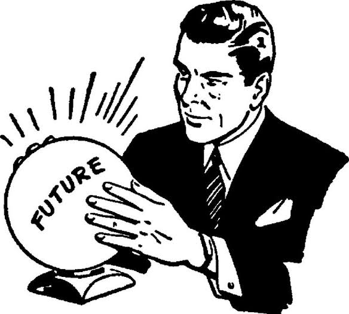

## The ABCD Framework

A useful way to remember prediction-model evaluation:

- **A** = Calibration-in-the-large
- **B** = Calibration slope
- **C** = C-statistic / Discrimination
- **D** = Decision curve / Clinical usefulness

## Case Study: Cognitive Impairment Prediction

We evaluate a logistic regression model predicting cognitive impairment from:

- Age
- Sex (male)
- Tau protein
- Phosphorylated tau
- Amyloid beta 42
- APOE genotype (6 variants)

**Outcome**: Impaired vs Control (gold-standard neuropsychological testing)

## The Prediction Model

The model was trained on a separate training set:

$$impairment_i \sim age + male + tau + p\_tau + Ab\_42 + genotype$$

where predictors are measured in cerebrospinal fluid via lumbar puncture.

## Dataset Visualization

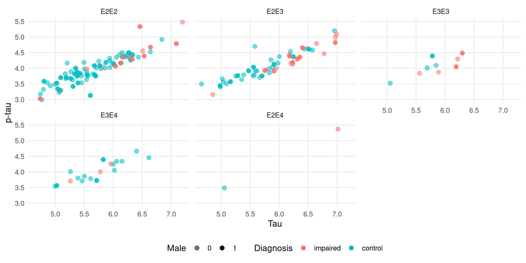

Tau vs p-tau by genotype and diagnosis

## Biomarker Distributions

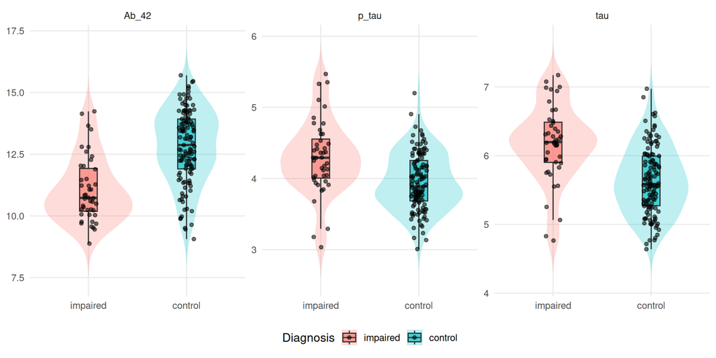

Distribution of biomarkers by diagnosis

# Evaluating Prediction Models

## What We Need

A prediction model can be evaluated from two things:

- What actually happened (observed outcome)
- What the model predicted (predicted probabilities)

Here we use predictions from a pre-trained logistic regression model.

## The Validation Data

Class = observed outcome. `.pred_impaired` = predicted probability of impairment.

```
   .pred_impaired .pred_control    Class
1      0.40306887     0.5969311  control
3      0.66547506     0.3345249  control
5      0.71154002     0.2884600  control
7      0.29307658     0.7069234  control
9      0.01425278     0.9857472  control
11     0.56453589     0.4354641 impaired
```

## Confusion Matrix

How many were correctly classified?

```
          Truth
Prediction impaired control
  impaired       25      14
  control        19     109
```

## Accuracy: How Often Correct?

> How often does the model get the class right?

$$Accuracy = \frac{TP + TN}{TP + TN + FP + FN}$$

```
# A tibble: 1 × 3
  .metric  .estimator .estimate
  <chr>    <chr>          <dbl>
1 accuracy binary         0.802
```

**Accuracy = 0.802** (80.2% classified correctly)

## The Problem with Accuracy

Accuracy is easy to understand but has an important limitation.

It does not tell us **which class** the model gets wrong.

It can be misleading when classes are **unbalanced**.

Example: If 95% are controls, a model that always predicts “control” has 95% accuracy, despite failing to identify **any** impaired participants.

## Specificity: Avoiding False Positives

> Among people who are **not** “impaired”, how many does the model correctly identify?

Specificity measures how well the model identifies the **negative class** (controls).

```
# A tibble: 1 × 3
  .metric     .estimator .estimate
  <chr>       <chr>          <dbl>
1 specificity binary         0.886
```

**Specificity = 0.886** (88.6% of controls correctly identified)

## Sensitivity: Avoiding False Negatives

> Among people who **are** “impaired”, how many does the model correctly identify?

Sensitivity measures how well the model identifies the **positive class** (impaired).

```
# A tibble: 1 × 3
  .metric     .estimator .estimate
  <chr>       <chr>          <dbl>
1 sensitivity binary         0.568
```

**Sensitivity = 0.568** (56.8% of impaired correctly identified)

## Sensitivity vs Specificity

### Specificity = 88.6%

- Good at identifying controls
- Few false positives
- Conservative about calling impairment

### Sensitivity = 56.8%

- Misses many impaired cases
- More false negatives
- Not aggressive enough

## Discussion Task

**Discuss with your neighbor:**

- Which diagnosis would you prefer a **lower** probability threshold? Why?
- Which diagnosis would you prefer a **higher** probability threshold? Why?

Consider consequences: - Cost of treatment - Side-effects - Effectiveness of treatment

## ROC and AUC

Instead of choosing one threshold, we can look at model discrimination across **all** possible thresholds.

The ROC curve shows sensitivity against 1 − specificity.

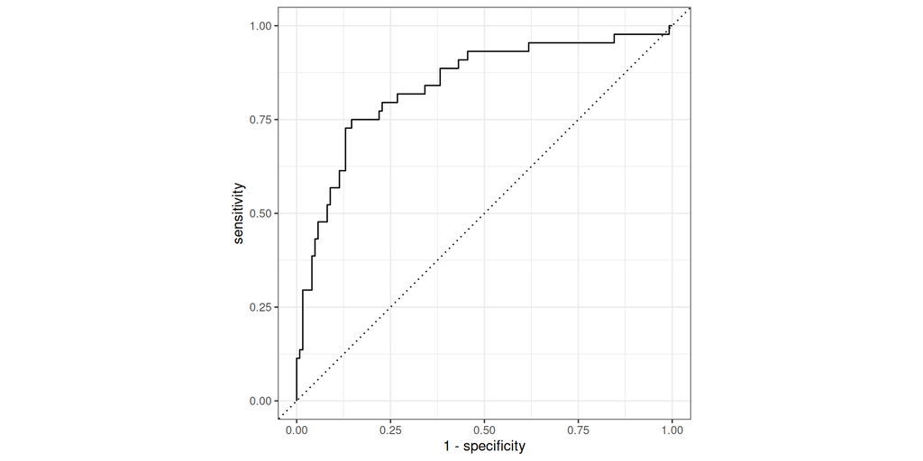

ROC curve for cognitive impairment prediction

## Area Under the Curve

```
# A tibble: 1 × 3
  .metric .estimator .estimate
  <chr>   <chr>          <dbl>
1 roc_auc binary         0.840
```

**AUC** = area under the ROC curve

## Key Idea

> No single metric evaluates a prediction model completely.

A useful model should:

- Discriminate well - Produce sensible probabilities
- Lead to better decisions

## From Data to Probability

```
flowchart LR
    A["🐛"] --> B["Model prediction"] --> C["0.18"]

    style B fill:#FFF0D9,stroke:#D99024,color:#222
    style C fill:#E2F0D9,stroke:#548235,color:#222
```

## From Data to Probability

```
flowchart LR
    A["😄"] --> B["Model prediction"] --> C["0.84"]

    style B fill:#FFF0D9,stroke:#D99024,color:#222
    style C fill:#E2F0D9,stroke:#548235,color:#222
```

## ABCD Framework in Detail

[figure not shown]

[figure not shown]

## Model calibration

So the CITL measures a systematic bias: the average predicted probability is too large. The calibration slope is a measure of the association between observed and predicted tisk of the outcome event across the whole range of predicted risks. So not a systematic error, but a errors across the prediction range.

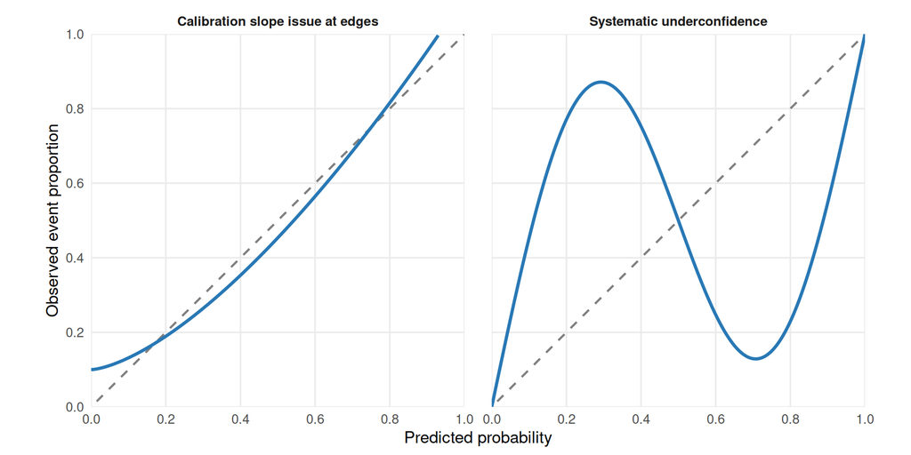

## Are the Probabilities Accurate?

Calibration asks a different question:

> When the model says 70%, does the event happen about 70% of the time?

A simple calibration plot compares predicted probability with the observed proportion.

## A: Calibration in the large

> Are predictions systematically too high or too low?

Calibration-in-the-large (CITL) assesses whether predicted risks are systematically too high or too low overall.

## Calibration-in-the-large

To estimate the **CITL**, we use the following logistic regression model:

$$logit(P(Y = 1)) = α + \text{offset}(logit(\hat{p}_i))$$

- $\hat{p}_i$ is the predicted risk from the prediction model
- the coefficient of logit($\hat{p}_i$) is fixed at 1.

The estimated intercept α is the calibration-in-the-large.

- citl = 1: no overall calibration-in-the-large error.
- citl < 1: predicted risks are too high on average.
- citl > 1: predicted risks are too low on average.

## Calibration-in-the-large part 2 (repeat?)

- Poisson regression offset: adjusts the expected count for exposure,
- Logistic regression contributes a known term to the log-odds, with its coefficient fixed at 1.

Our model is:

$$logit(q_i) = α + \text{offset}(o_i)$$
where $o_i$ are the logit-transformed estimated probabilities from the prediction-model,

$$o_i = logit(\hat{p}_i)$$

```
# A tibble: 1 × 7
  term        estimate std.error statistic p.value conf.low conf.high
  <chr>          <dbl>     <dbl>     <dbl>   <dbl>    <dbl>     <dbl>
1 (Intercept)    0.817     0.223    -0.905   0.365    0.524      1.26
```

## B: The calibration slope

> Are predictions too extreme or not extreme enough?

To estimate the calibration **slope**, we use another logistic regression model:

$$logit(P(Y = 1)) = α + ζlogit(\hat{p})$$

- estimating ζ (*“zeta”*),

also estimates a separate intercept α.

- ζ = 1: ideal calibration slope.
- ζ < 1: typically indicates overfitting, with predictions that are too extreme.
- ζ > 1: typically indicates underfitting, with predictions that are not extreme enough.

```
# A tibble: 2 × 7
  term        estimate std.error statistic     p.value conf.low conf.high
  <chr>          <dbl>     <dbl>     <dbl>       <dbl>    <dbl>     <dbl>
1 (Intercept)   -0.402     0.214     -1.88 0.0603        -0.822    0.0213
2 logit_p        0.639     0.124      5.17 0.000000231    0.410    0.897
```

## Visualizing calibration

[output not shown]

## Calibration plot

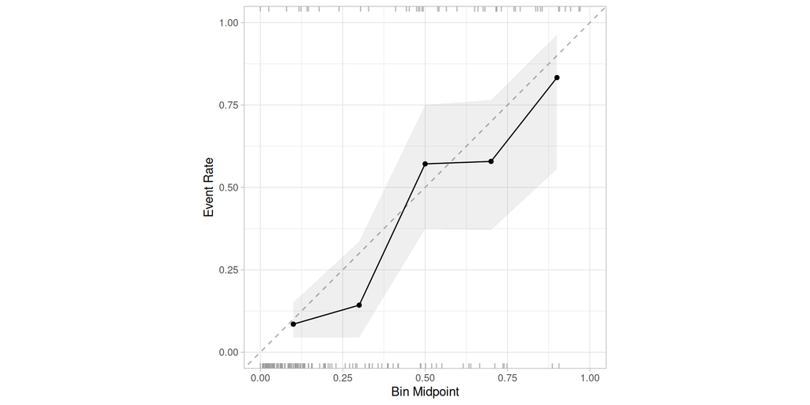

Figure 1

## Discrimination using the concordance statistic

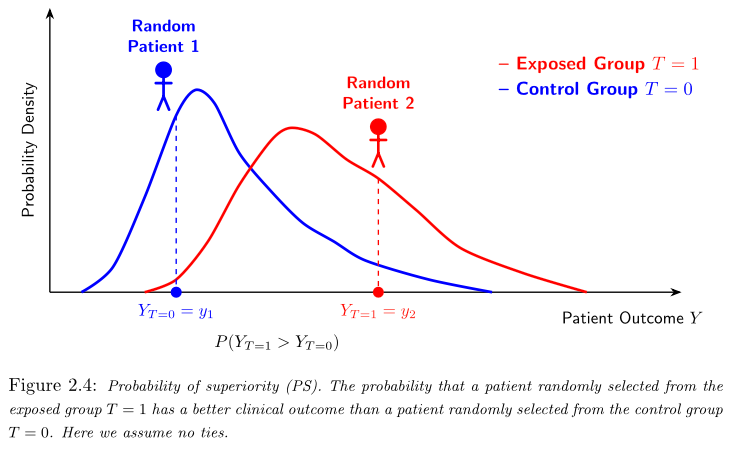

## D: Decision Curve

> Does using the model improve clinical decisions?

*More in Case 3* - not discussed in this session!

## Internal validation

[figure not shown]

What if one image is more difficult?

## Cross-validation

```
flowchart LR
    subgraph CV["5-Fold Cross-Validation"]
        direction TB

        subgraph R1["Iteration 1"]
            direction LR
            A11["Test"]:::test --- A12["Train"]:::train --- A13["Train"]:::train --- A14["Train"]:::train --- A15["Train"]:::train
        end

        subgraph R2["Iteration 2"]
            direction LR
            A21["Train"]:::train --- A22["Test"]:::test --- A23["Train"]:::train --- A24["Train"]:::train --- A25["Train"]:::train
        end

        subgraph R3["Iteration 3"]
            direction LR
            A31["Train"]:::train --- A32["Train"]:::train --- A33["Test"]:::test --- A34["Train"]:::train --- A35["Train"]:::train
        end

        subgraph R4["Iteration 4"]
            direction LR
            A41["Train"]:::train --- A42["Train"]:::train --- A43["Train"]:::train --- A44["Test"]:::test --- A45["Train"]:::train
        end

        subgraph R5["Iteration 5"]
            direction LR
            A51["Train"]:::train --- A52["Train"]:::train --- A53["Train"]:::train --- A54["Train"]:::train --- A55["Test"]:::test
        end
    end

    A15 ~~~ M1["Metric 1"]:::metric
    A25 ~~~ M2["Metric 2"]:::metric
    A35 ~~~ M3["Metric 3"]:::metric
    A45 ~~~ M4["Metric 4"]:::metric
    A55 ~~~ M5["Metric 5"]:::metric

    M1 --> AVG["Average<br/>performance"]:::average
    M2 --> AVG
    M3 --> AVG
    M4 --> AVG
    M5 --> AVG

    classDef train fill:#55c5d5,stroke:#55c5d5,color:#000
    classDef test fill:#d91b91,stroke:#d91b91,color:#fff
    classDef metric fill:#8cf4f5,stroke:#8cf4f5,color:#000
    classDef average fill:#8cf4f5,stroke:#8cf4f5,color:#000
    style CV fill:transparent,stroke:transparent
    style R1 fill:transparent,stroke:transparent
    style R2 fill:transparent,stroke:transparent
    style R3 fill:transparent,stroke:transparent
    style R4 fill:transparent,stroke:transparent
    style R5 fill:transparent,stroke:transparent
```

Figure 2: Cross-validation for internal validation’.

## External validation

1. **Temporal validation:**  
   Develop the model using data from an earlier time period and evaluate it using patients from a later time period. This tests whether the model continues to work as patients and clinical practice change over time.
2. **Geographical validation:**  
   Develop the model using data from one geographical location, such as a hospital or country, and evaluate it using data from another location. This tests whether the model generalises to a different population or healthcare setting.
3. **Domain validation:**  
   Develop the model in one type of healthcare setting and evaluate it in another. For example, a model developed using patients from a specialist hospital could be evaluated in primary care.
4. **Cross-setting validation:**  
   Develop the model using one study and evaluate it using an entirely independent study. This is often the strongest form of external validation because the validation data were collected independently of the model development process.

## When to use internal and external validation?

[figure not shown]

## Sample size calculation in binary prediction studies

[figure not shown]

## Manual SSC

For sample-size planning, we need to select:

- the anticipated *C*-statistic, $C$;
- the anticipated event proportion, $\phi$; and
- the desired precision, expressed as $SE(C)$.

## Using the C-statistic

$$𝐶 = 0.70, \\
𝜙 = 0.10.$$

If we want the *C*-statistic to have an approximate 95% confidence interval of $\pm0.05$, we need approximately

$$SE(C)
\approx \sqrt{\frac{0.70(1 - 0.70)}{1413^2(0.10)(1 - 0.10)} \Bigg[1 + (1413 \times 0.10 - 1)\frac{1 - 0.70}{2 - 0.70} + (1413 \times (1 - 0.10) - 1)\frac{0.70}{1 + 0.70}\Bigg]}
\approx 0.0255$$

## In practice:

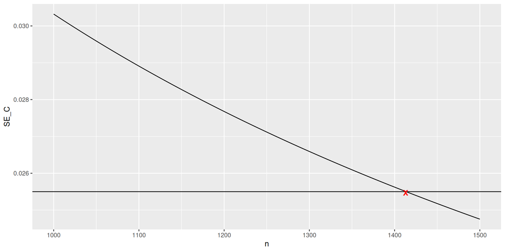

## R’s `pmsampsize` library

```r
pmsampsize::pmsampsize(
    type = "b", # binary
    cstatistic = 0.89, # concordance/AUC
    parameters = 24, # covariates
    prevalence = 0.174 # cognitive impairment
    )
```

## R’s `pmsampsize` output

```
Given input C-statistic = 0.89  & prevalence = 0.174
Cox-Snell R-sq = 0.2902

NB: Assuming 0.05 acceptable difference in apparent & adjusted R-squared
NB: Assuming 0.05 margin of error in estimation of intercept
NB: Events per Predictor Parameter (EPP) assumes prevalence = 0.174

           Samp_size Shrinkage Parameter CS_Rsq Max_Rsq Nag_Rsq  EPP
Criteria 1       617     0.900        24 0.2902   0.603   0.481 4.47
Criteria 2       661     0.906        24 0.2902   0.603   0.481 4.79
Criteria 3       221     0.906        24 0.2902   0.603   0.481 1.60
Final            661     0.906        24 0.2902   0.603   0.481 4.79

 Minimum sample size required for new model development based on user inputs = 661,
 with 116 events (assuming an outcome prevalence = 0.174) and an EPP = 4.79
```

# Summary: Evaluation Toolkit

| Question | Measure |
| --- | --- |
| Does the model classify correctly at this threshold? | Accuracy |
| Does it avoid false positives? | Specificity |
| Does it avoid false negatives? | Sensitivity |
| Can it distinguish the two outcomes? | ROC / AUC |
| Are the probabilities accurate? | Calibration |
| Does it improve clinical decisions? | Decision curve |
| What is the effect of a predictor? | Effect estimate |